# 2. EDA. Ejercicios

Febrero 2024

1. Why is EDA an important part of a modeling exercise?
2. How many aesthetic elements of visualization can you think of? List them and explain how they could be mapped to variables in different scales.
3. The data set explored in this chapter was in wide format: each row was a single respondent. However, discrete choice data is often found in long format: each row is a choice situation, and each individual now appears in the table as many times as they faced a choice situation. Would this change in any way how you approach data analysis? mas que nada estos dos modos sirven para visualizar datos

En el formato largo, cada fila es como un pedacito de detalle extra. En lugar de agrupar todas las respuestas de alguien en una sola fila (como en el formato ancho), ahora cada fila representa una sola elección que hizo alguien. Esto significa que podemos meter la lupa y ver más de cerca las decisiones individuales, lo que podría sacar a la luz patrones que antes estaban escondidos.

Cambiar al formato largo se lleva mejor con el tipo de modelos que usamos para analizar elecciones. Cada observación en los datos ahora coincide con una elección específica de una persona, lo que hace más fácil usar técnicas específicas para este tipo de datos, como los modelos multinomiales o condicionales para elecciones.

Con el formato largo, es posible que necesitemos hacer algunos ajustes preliminares en los datos antes de lanzarnos al análisis. Esto puede significar crear nuevas variables que nos ayuden a entender mejor las elecciones o cambiar la forma en que están organizados los datos para que sea más fácil trabajar con ellos.

Análisis de relaciones a lo largo del tiempo: Si estamos siguiendo a las mismas personas a lo largo del tiempo, el formato largo es como nuestra mejor herramienta. Nos permite ver cómo cambian las elecciones de cada persona con el tiempo, lo cual sería más complicado de hacer con el formato ancho.

En resumen, el cambio al formato de largo puede mejorar la capacidad de análisis detallado de datos de elección discreta y facilitar la aplicación de técnicas específicas para este tipo de datos. Sin embargo, también puede requerir ajustes en el procesamiento y la manipulación de datos antes del análisis.

4. How many variables are there in this data set and of which type (i.e., categorical/quantitative)?

```r
data("Car")
glimpse(Car)
```

```
## Rows: 4,654
## Columns: 70
## $ choice     <fct> choice1, choice2, choice5, choice5, choice5, choice5, choic…
## $ college    <dbl> 0, 1, 0, 0, 0, 0, 1, 1, 0, 1, 1, 1, 1, 0, 1, 1, 1, 0, 1, 1,…
## $ hsg2       <dbl> 0, 1, 1, 0, 1, 0, 1, 0, 0, 0, 0, 1, 0, 0, 0, 0, 1, 0, 1, 0,…
## $ coml5      <dbl> 0, 1, 0, 1, 0, 0, 1, 1, 0, 0, 0, 0, 0, 0, 0, 0, 1, 0, 0, 1,…
## $ type1      <fct> van, regcar, regcar, regcar, regcar, truck, regcar, regcar,…
## $ type2      <fct> regcar, van, truck, truck, truck, regcar, van, van, sportca…
## $ type3      <fct> van, regcar, regcar, regcar, regcar, truck, regcar, regcar,…
## $ type4      <fct> stwagon, stwagon, van, van, van, van, stwagon, stwagon, reg…
## $ type5      <fct> van, regcar, regcar, regcar, regcar, truck, regcar, regcar,…
## $ type6      <fct> truck, truck, stwagon, stwagon, stwagon, stwagon, truck, tr…
## $ fuel1      <fct> cng, methanol, cng, methanol, cng, cng, methanol, methanol,…
## $ fuel2      <fct> cng, methanol, cng, methanol, cng, cng, methanol, methanol,…
## $ fuel3      <fct> electric, cng, electric, cng, electric, electric, cng, cng,…
```

[output cut: 57 more lines]

```r
Car$college <- factor(Car$college, levels = c("0", "1"), labels = c("No", "Yes"))

summary(Car)
```

```
##      choice     college         hsg2           coml5             type1
##  choice1: 887   No :1079   Min.   :0.000   Min.   :0.0000   regcar  :3138
##  choice2: 269   Yes:3575   1st Qu.:0.000   1st Qu.:0.0000   sportuv : 283
##  choice3:1345              Median :0.000   Median :0.0000   sportcar: 199
##  choice4: 349              Mean   :0.222   Mean   :0.3578   stwagon : 137
##  choice5:1499              3rd Qu.:0.000   3rd Qu.:1.0000   truck   : 487
##  choice6: 305              Max.   :1.000   Max.   :1.0000   van     : 410
##       type2           type3           type4           type5
##  regcar  : 769   regcar  :3138   regcar  : 362   regcar  :3138
##  sportuv :  35   sportuv : 283   sportuv :  57   sportuv : 283
##  sportcar:  80   sportcar: 199   sportcar:  74   sportcar: 199
##  stwagon : 991   stwagon : 137   stwagon :1124   stwagon : 137
##  truck   :1851   truck   : 487   truck   :1175   truck   : 487
##  van     : 928   van     : 410   van     :1862   van     : 410
##       type6           fuel1           fuel2           fuel3
##  regcar  : 385   gasoline:   0   gasoline:   0   gasoline:   0
##  sportuv : 107   methanol:3476   methanol:3476   methanol:   0
##  sportcar: 129   cng     :1178   cng     :1178   cng     :2330
##  stwagon :1920   electric:   0   electric:   0   electric:2324
##  truck   :1141
##  van     : 972
##       fuel4           fuel5           fuel6          price1
##  gasoline:   0   gasoline:3479   gasoline:3479   Min.   : 0.5987
##  methanol:   0   methanol:   0   methanol:   0   1st Qu.: 3.0863
##  cng     :2330   cng     :   0   cng     :   0   Median : 4.1387
##  electric:2324   electric:1175   electric:1175   Mean   : 4.2963
##                                                  3rd Qu.: 5.2423
##                                                  Max.   :17.3706
##      price2            price3            price4            price5
##  Min.   : 0.5987   Min.   : 0.5987   Min.   : 0.5987   Min.   : 0.6352
##  1st Qu.: 3.0863   1st Qu.: 2.9936   1st Qu.: 2.9936   1st Qu.: 2.9072
##  Median : 4.1387   Median : 4.0396   Median : 4.0396   Median : 4.0396
##  Mean   : 4.2963   Mean   : 4.1732   Mean   : 4.1732   Mean   : 4.1500
##  3rd Qu.: 5.2423   3rd Qu.: 5.1435   3rd Qu.: 5.1435   3rd Qu.: 5.2423
##  Max.   :17.3706   Max.   :17.3706   Max.   :17.3706   Max.   :17.3706
##      price6            range1          range2          range3
##  Min.   : 0.6352   Min.   : 50.0   Min.   : 50.0   Min.   : 75.0
##  1st Qu.: 2.9072   1st Qu.:125.0   1st Qu.:125.0   1st Qu.:250.0
##  Median : 4.0396   Median :125.0   Median :125.0   Median :250.0
##  Mean   : 4.1500   Mean   :160.5   Mean   :160.5   Mean   :240.4
```

[output cut: 64 more lines]

```
##  Max.   :8.000   Max.   :8.000   Max.   :8.000   Max.   :8.00   Max.   :8.00
##     station1          station2          station3         station4
##  Min.   :0.00000   Min.   :0.00000   Min.   :0.1000   Min.   :0.1000
##  1st Qu.:0.00000   1st Qu.:0.00000   1st Qu.:0.1000   1st Qu.:0.1000
##  Median :0.00000   Median :0.00000   Median :0.3000   Median :0.3000
##  Mean   :0.08951   Mean   :0.08951   Mean   :0.3828   Mean   :0.3828
##  3rd Qu.:0.10000   3rd Qu.:0.10000   3rd Qu.:0.7000   3rd Qu.:0.7000
##  Max.   :0.70000   Max.   :0.70000   Max.   :0.7000   Max.   :0.7000
##     station5         station6
##  Min.   :0.1000   Min.   :0.1000
##  1st Qu.:0.7000   1st Qu.:0.7000
##  Median :1.0000   Median :1.0000
##  Mean   :0.8239   Mean   :0.8239
##  3rd Qu.:1.0000   3rd Qu.:1.0000
##  Max.   :1.0000   Max.   :1.0000
```

```r
car_alluvia <- Car |>
  select(college, type1, type2, choice) |>
  group_by(college, type1, type2, choice) |>
  summarize(frequency = n(), .groups = "drop")
```

5. Choose four relevant categorical variables from this data set and describe them using univariate, bivariate, and multivariate techniques. Discuss your results.

Univariate

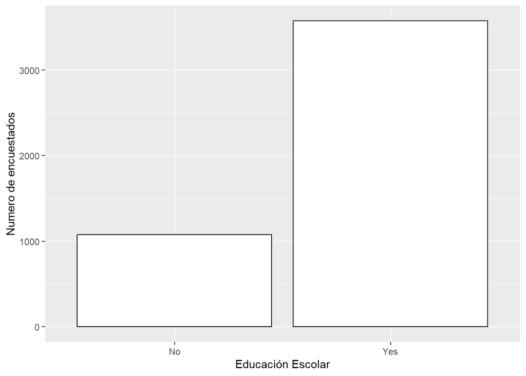

```r
Car |> ggplot(aes(x = college)) +
  geom_bar(color = "black", fill = "white") +
  labs(x = "Educación Escolar", y="Numero de encuestados")
```

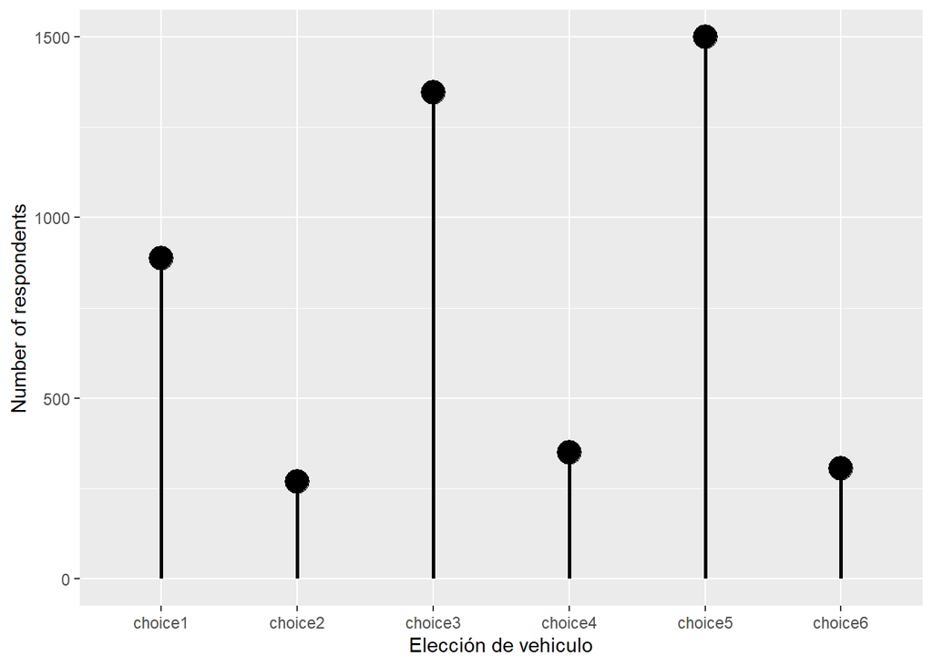

```r
Car |> group_by(choice) |> summarize(n = n()) |>
  ggplot(aes(x = choice, xend = choice, y = n, yend = 0)) +
  geom_point(color = "black", fill = "white", size = 6) +
  geom_segment(linewidth = 1) +
  labs(x = "Elección de vehiculo", y = "Number of respondents")
```

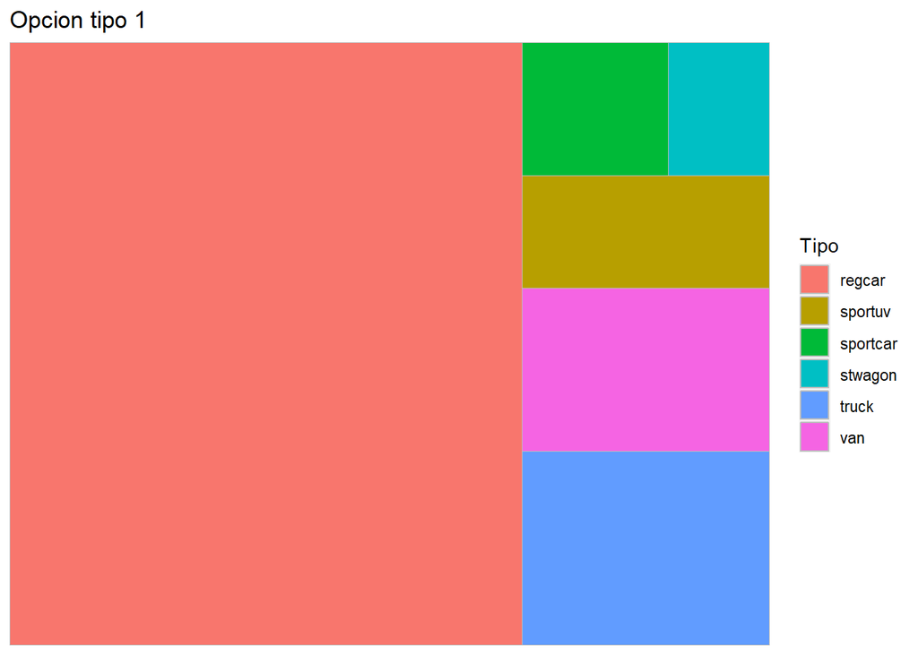

```r
Car |> group_by(type1) |> summarize(n = n()) |>
ggplot(aes(fill = type1, area = n)) +
  geom_treemap() +
  labs(title = "Opcion tipo 1", fill="Tipo")
```

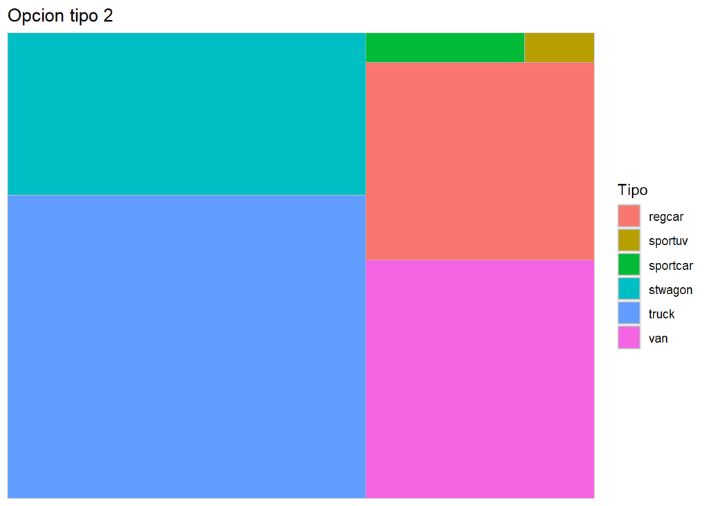

```r
Car |> group_by(type2) |> summarize(n = n()) |>
ggplot(aes(fill = type2, area = n)) +
  geom_treemap() +
  labs(title = "Opcion tipo 2", fill="Tipo")
```

Bivariado

```r
Car |>  select(choice, cost1) |> summary()
```

```
##      choice         cost1
##  choice1: 887   Min.   :1.000
##  choice2: 269   1st Qu.:2.000
##  choice3:1345   Median :4.000
##  choice4: 349   Mean   :4.154
##  choice5:1499   3rd Qu.:8.000
##  choice6: 305   Max.   :8.000
```

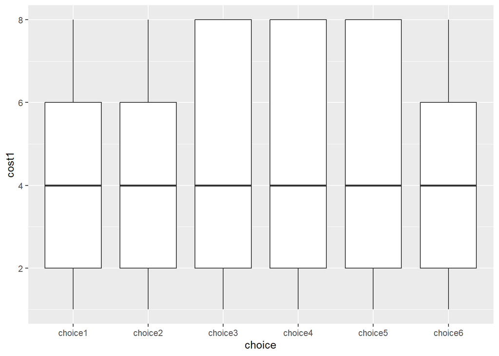

```r
Car |>  ggplot(aes(x = choice, y = cost1)) +
  geom_boxplot()
```

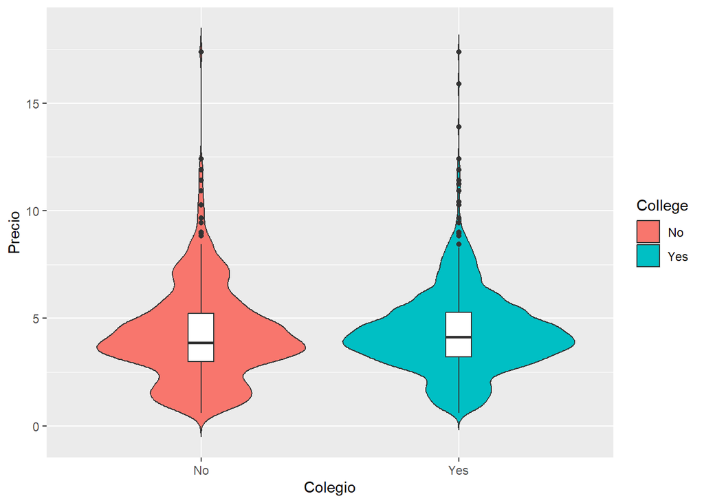

```r
Car |>  ggplot(aes(x = college, y = price1, fill = college)) +
  geom_violin(trim = FALSE) +
  geom_boxplot(width = 0.1, fill = "white") +
  labs(x="Colegio", y = expression("Precio"), fill = "College")
```

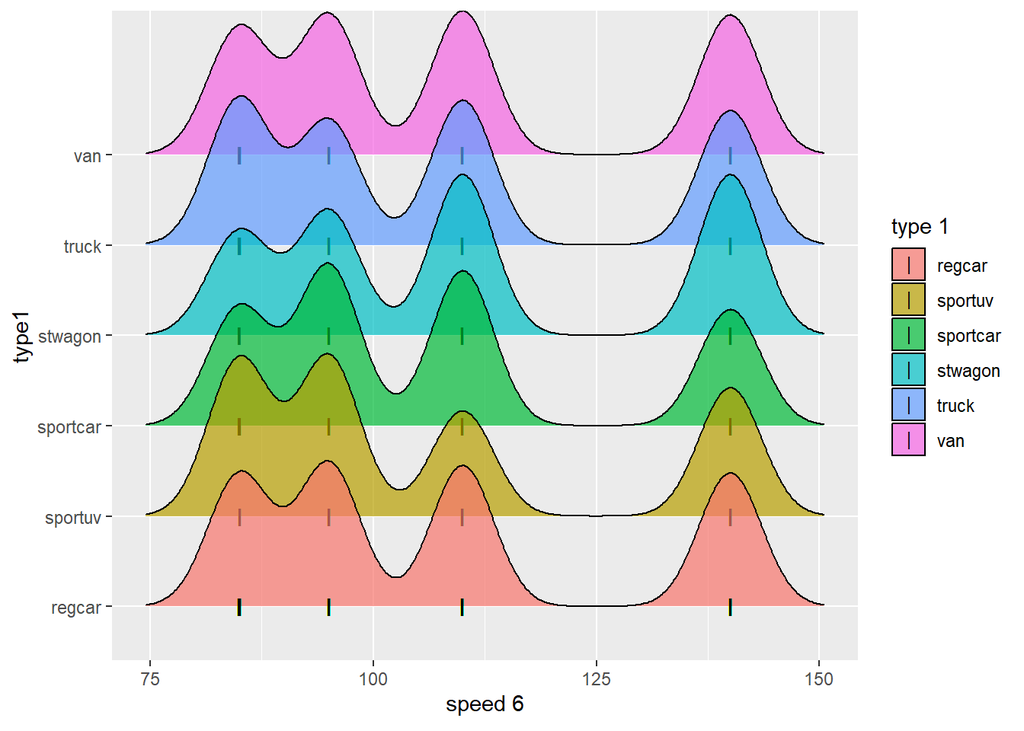

```r
Car %>% ggplot(aes(x = speed6, y = type1, fill = type1)) +
  geom_density_ridges(jittered_points = TRUE, bandwidth = 3.5,
                      position = position_points_jitter(width = 0.05, height = 0),
                      point_shape = '|', point_size = 3, point_alpha = 1, alpha = 0.7) +
  labs(y="type1", x = expression("speed 6"), fill = "type 1")
```

Relación entre dos variables categóricas

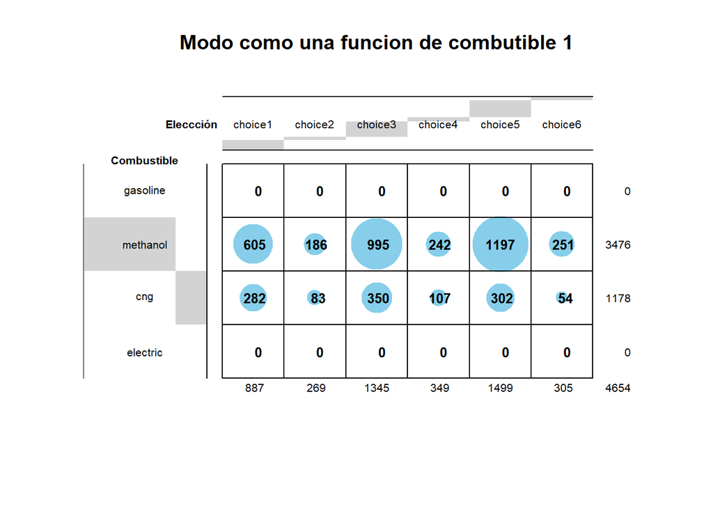

```r
tableau <- table(Car$choice, Car$fuel1)

balloonplot(
  as.table(tableau),
  xlab = "Eleccción",
  ylab = "Combustible",
  dotsize = 3/max(strwidth(19), strheight(19)),
  dotcolor = "skyblue",
  text.size = 0.65,
  main = "Modo como una funcion de combutible 1",
  label = TRUE,
  label.size = 0.80,
  scale.method = c("volume"),
  scale.range = c("absolute"),
  colmar = 1, rowmar = 2,
  show.zeros = TRUE,
  show.margins = TRUE,
  cum.margins = TRUE
)
```

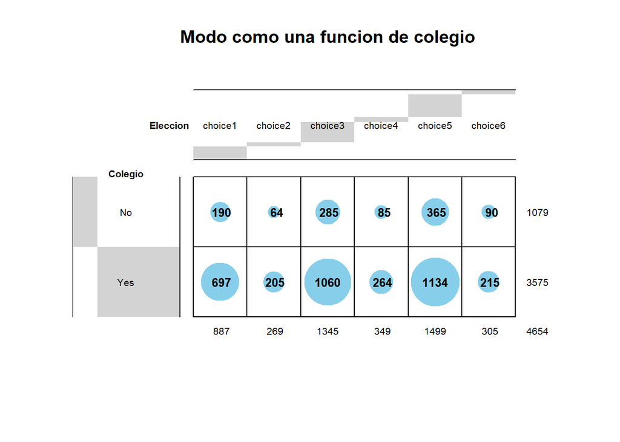

```r
tableau <- table(Car$choice, Car$college)

balloonplot(
  as.table(tableau),
  xlab = "Eleccion",
  ylab = "Colegio",
  dotsize = 3/max(strwidth(19), strheight(19)),
  dotcolor = "skyblue",
  text.size = 0.65,
  main = "Modo como una funcion de colegio",
  label = TRUE,
  label.size = 0.80,
  scale.method = c("volume"),
  scale.range = c("absolute"),
  colmar = 1, rowmar = 2,
  show.zeros = TRUE,
  show.margins = TRUE,
  cum.margins = TRUE
)
```

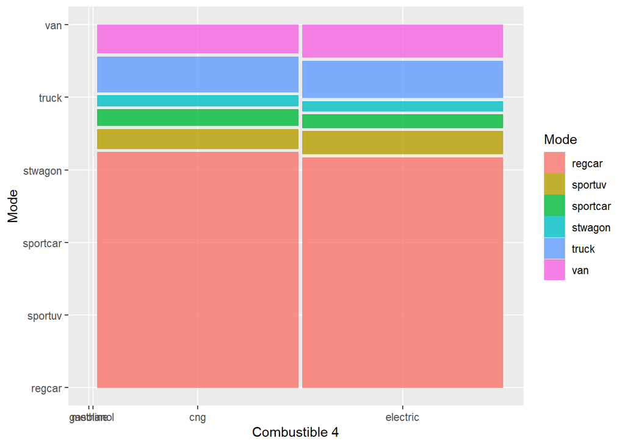

```r
Car |>  ggplot() +
  geom_mosaic(aes(x = product(type1, fuel4), fill = type1)) +
  labs(x = "Combustible 4", y = "Mode", fill = "Mode")
```

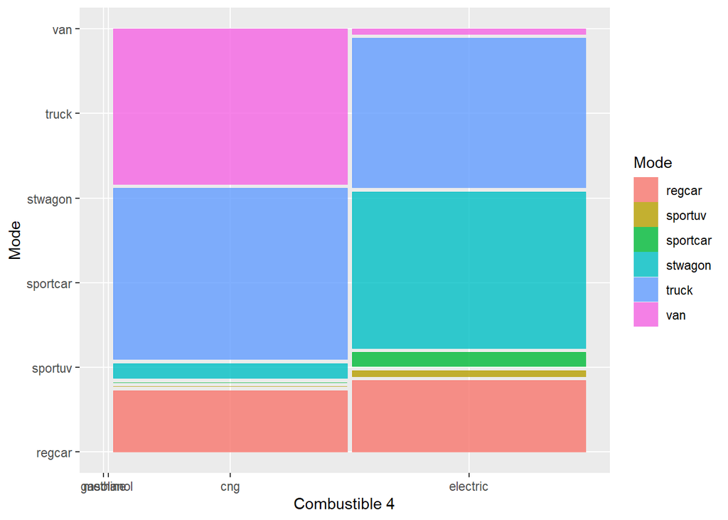

```r
Car |>  ggplot() +
  geom_mosaic(aes(x = product(type2, fuel4), fill = type2)) +
  labs(x = "Combustible 4", y = "Mode", fill = "Mode")
```

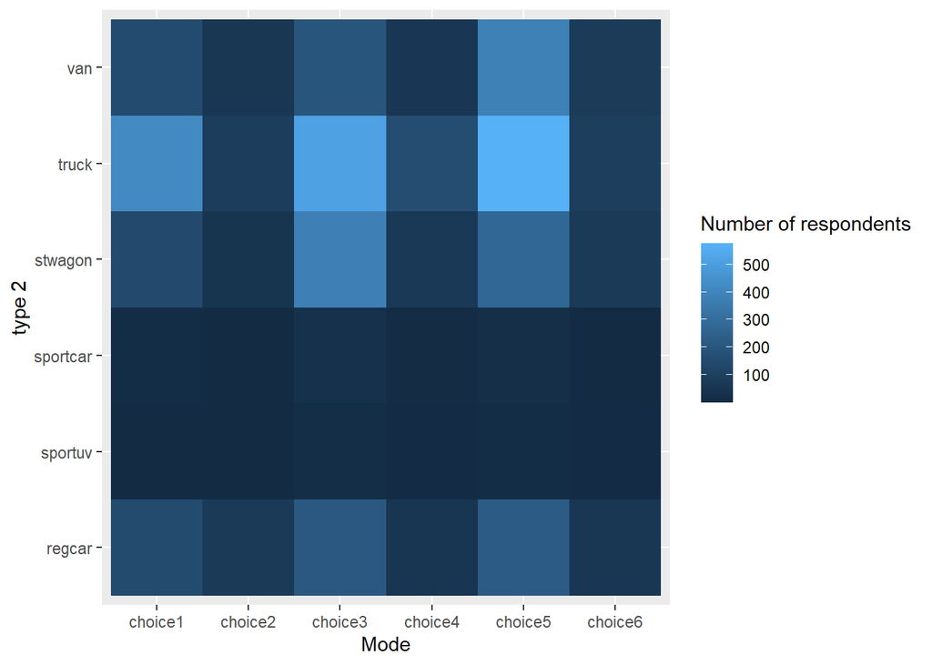

```r
Car |> group_by(choice, type2) |>
  summarize(n = n(), .groups = "drop") |>
  ggplot(aes(x = choice, y = type2)) +
  geom_tile(aes(fill = n)) +
  labs(x = "Mode", y = "type 2", fill = "Number of respondents")
```

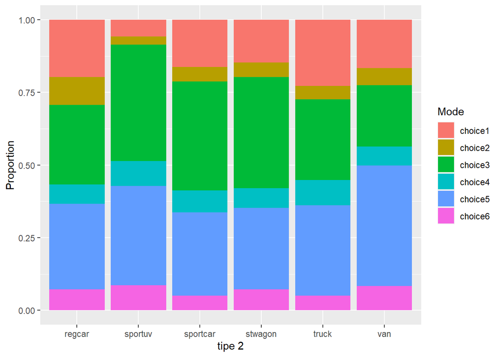

```r
Car |> ggplot(aes(x = type2, fill = choice)) +
  geom_bar(position = "fill") +
  labs(y = "Proportion", x = "tipe 2", fill="Mode")
```

Multivariate

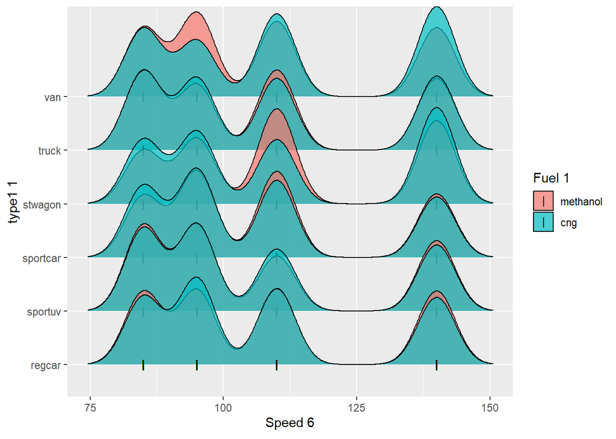

```r
ggplot(data = Car, aes(x = speed6, y = type1, fill = fuel1)) +
  geom_density_ridges(jittered_points = TRUE, bandwidth = 3.5,
                      position = position_points_jitter(width = 0.05, height = 0),
                      point_shape = '|', point_size = 3, point_alpha = 1, alpha = 0.7) +
  labs(y="type1 1", x = expression("Speed 6"),
       fill = "Fuel 1")
```

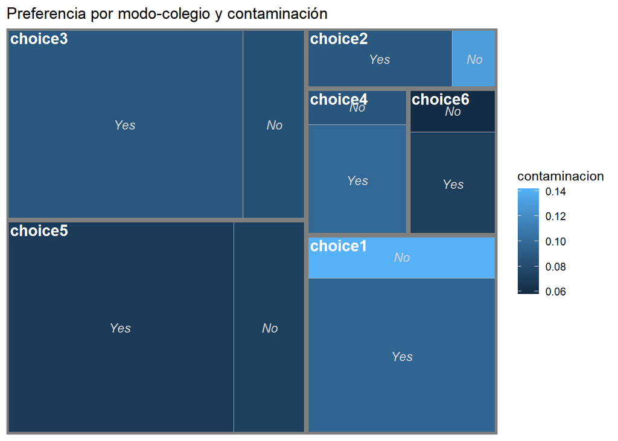

```r
ggplot(data = Car |>  group_by(choice, college) |>
         summarize(n = n(), pollution1 = mean(pollution1), .groups = "drop"),
       aes(area = n, fill = pollution1, label = college, subgroup = choice)) +
  geom_treemap() +
  geom_treemap_subgroup_border(size = 5)+
  geom_treemap_subgroup_text(fontface = "bold", colour = "white", place = "topleft",
                             size = 13, grow = FALSE) +
  geom_treemap_text(fontface = "italic", colour = "lightgray", place = "centre", size = 10,
                    grow = FALSE) +
  labs(title = "Preferencia por modo-colegio y contaminación",
       fill = expression("contaminacion"))
```

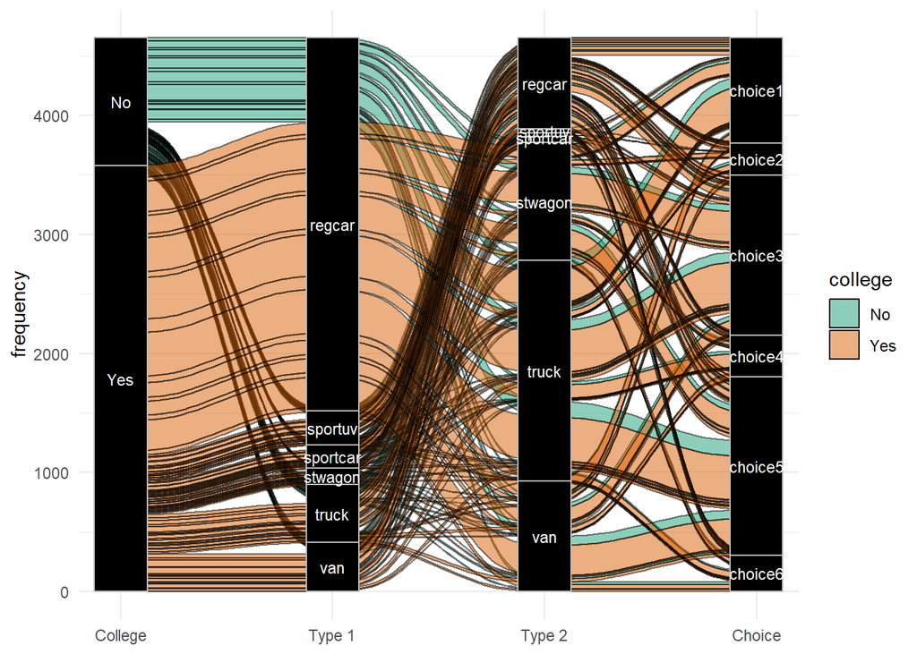

```r
car_alluvia |>
  ggplot(aes(y = frequency, axis1 = college, axis2 = type1, axis3 = type2, axis4=choice)) +
  geom_alluvium(aes(fill = college), width = 1/12, color = "black") +
  geom_stratum(width = 1/4, fill = "black", color = "grey") +
  geom_text(stat = "stratum", aes(label = after_stat(stratum)), color = "white", size = 3) +
  scale_x_discrete(limits = c("College", "Type 1","Type 2", "Choice"), expand = c(.05, .05)) +
  scale_fill_brewer(type = "qual", palette = "Dark2") +
  theme_minimal()
```

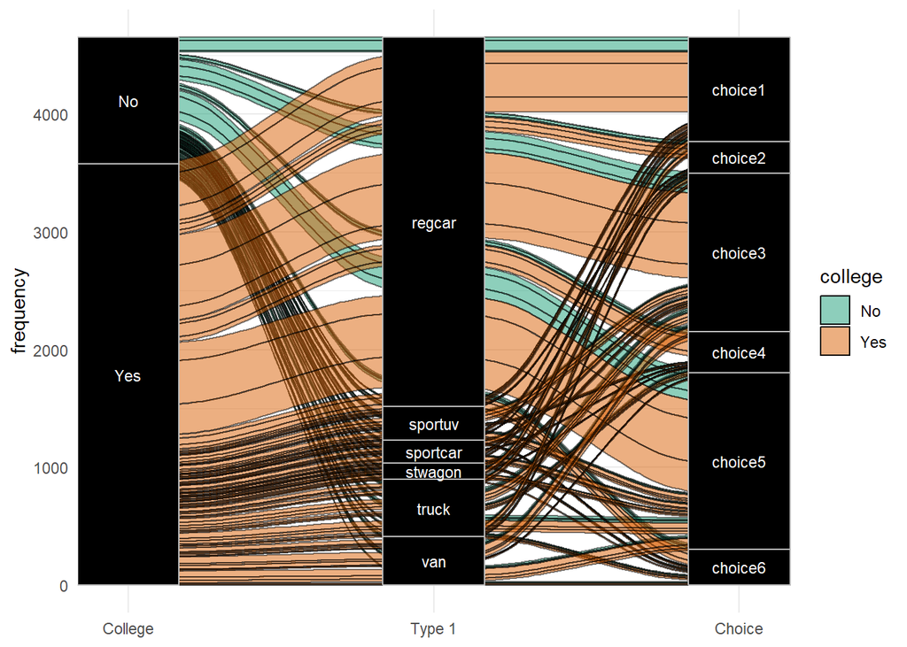

```r
car_alluvia |>
  ggplot(aes(y = frequency, axis1 = college, axis2 = type1, axis3=choice)) +
  geom_alluvium(aes(fill = college), width = 1/12, color = "black") +
  geom_stratum(width = 1/3, fill = "black", color = "grey") +
  geom_text(stat = "stratum", aes(label = after_stat(stratum)), color = "white", size = 3) +
  scale_x_discrete(limits = c("College", "Type 1", "Choice"), expand = c(.05, .05)) +
  scale_fill_brewer(type = "qual", palette = "Dark2") +
  theme_minimal()
```

6. What ideas about individuals’ choices regarding car do you develop from this EDA exercise?

la mayoria de los encuestados fueron personas con colegio, estas en su mayoria tienen preferencia hacia un auto regular en el tipo 1, la mayoria del combustible utilizado es el methanol, la mayoria de las elecciones rondan entre el modo 3 y 5 tanto para los que estan o no en el colegio